# Project: Investigate a Dataset - [tmdb-movies.csv]

- Introduction
- Data Wrangling
- Exploratory Data Analysis
- Conclusions

## Introduction

### Dataset Description

This dataset contains information about 10,000 movies collected from The Movie Database (TMDb), including user ratings and revenue, the dataset has the following columns :

- id : tmdb id
- imdb-id : id in the imdb site
- popularity : popularity percentage
- budget : budget written in full
- revenue : reveneu written in full
- original_title : original movie title
- cast : most notable cast members
- homepage : homepage address of the movie
- director : director name
- tagline : most notable tagline from the movie
- keywords : keywords related to the movie
- overview : a breif describtion of the movie
- runtime : movie runtime in minutes
- genres : genres the movie falls under
- production_company : production company of the movie
- release_date : release date of the movie month/day/year
- vote_count : number of voters
- vote_average : average rating of the movie
- release_year : release year
- budget_adj : budget in exponent form
- revenue_adj : revenue in exponent form

  ### Question(s) for Analysis

**Is there a trend or effect on revenue based on release date ?** If there is a trend or effect:

- Which quarter of the year performs generally better relative to movies of the same rating range ?
- Do movies - of the same group -meaning same rating rounded to the closest integer- released in the first half of a month -when most people have most of their salary still intact- perform better in terms of revenue than those released in the latter half ?
- Do movies -same relative criteria mention above- released later in the month get a bit less rating in thier relative rating group -like from 7 to 8, 8 to 9 and so on- ?

```python
# Use this cell to set up import statements for all of the packages that you
#   plan to use.
import pandas as pd
import numpy as np
import matplotlib.pyplot as plt
%matplotlib inline
import seaborn as sns
# Remember to include a 'magic word' so that your visualizations are plotted
#   inline with the notebook. See this page for more:
#   http://ipython.readthedocs.io/en/stable/interactive/magics.html
```

## Data Wrangling

Now I will load the data and:

1. Inspect it visually
2. check the data types and decide if some data types need to be converted
3. check for null values
4. decide what columns aren't necessary to answer my questions

```python
# load the data
df = pd.read_csv('tmdb-movies.csv')

# adjust vewing options to display the full width of the table for visual inspection plus a few extra columns in case of later modifications
pd.set_option('display.max_columns', 30)
# inspect the data
df.head()
```

|  | id | imdb_id | popularity | budget | revenue | original_title | cast | homepage | director | tagline | keywords | overview | runtime | genres | production_companies | release_date | vote_count | vote_average | release_year | budget_adj | revenue_adj |
| --- | --- | --- | --- | --- | --- | --- | --- | --- | --- | --- | --- | --- | --- | --- | --- | --- | --- | --- | --- | --- | --- |
| 0 | 135397 | tt0369610 | 32.985763 | 150000000 | 1513528810 | Jurassic World | Chris Pratt\|Bryce Dallas Howard\|Irrfan Khan\|Vi... | http://www.jurassicworld.com/ | Colin Trevorrow | The park is open. | monster\|dna\|tyrannosaurus rex\|velociraptor\|island | Twenty-two years after the events of Jurassic ... | 124 | Action\|Adventure\|Science Fiction\|Thriller | Universal Studios\|Amblin Entertainment\|Legenda... | 6/9/15 | 5562 | 6.5 | 2015 | 1.379999e+08 | 1.392446e+09 |
| 1 | 76341 | tt1392190 | 28.419936 | 150000000 | 378436354 | Mad Max: Fury Road | Tom Hardy\|Charlize Theron\|Hugh Keays-Byrne\|Nic... | http://www.madmaxmovie.com/ | George Miller | What a Lovely Day. | future\|chase\|post-apocalyptic\|dystopia\|australia | An apocalyptic story set in the furthest reach... | 120 | Action\|Adventure\|Science Fiction\|Thriller | Village Roadshow Pictures\|Kennedy Miller Produ... | 5/13/15 | 6185 | 7.1 | 2015 | 1.379999e+08 | 3.481613e+08 |
| 2 | 262500 | tt2908446 | 13.112507 | 110000000 | 295238201 | Insurgent | Shailene Woodley\|Theo James\|Kate Winslet\|Ansel... | http://www.thedivergentseries.movie/#insurgent | Robert Schwentke | One Choice Can Destroy You | based on novel\|revolution\|dystopia\|sequel\|dyst... | Beatrice Prior must confront her inner demons ... | 119 | Adventure\|Science Fiction\|Thriller | Summit Entertainment\|Mandeville Films\|Red Wago... | 3/18/15 | 2480 | 6.3 | 2015 | 1.012000e+08 | 2.716190e+08 |
| 3 | 140607 | tt2488496 | 11.173104 | 200000000 | 2068178225 | Star Wars: The Force Awakens | Harrison Ford\|Mark Hamill\|Carrie Fisher\|Adam D... | http://www.starwars.com/films/star-wars-episod... | J.J. Abrams | Every generation has a story. | android\|spaceship\|jedi\|space opera\|3d | Thirty years after defeating the Galactic Empi... | 136 | Action\|Adventure\|Science Fiction\|Fantasy | Lucasfilm\|Truenorth Productions\|Bad Robot | 12/15/15 | 5292 | 7.5 | 2015 | 1.839999e+08 | 1.902723e+09 |
| 4 | 168259 | tt2820852 | 9.335014 | 190000000 | 1506249360 | Furious 7 | Vin Diesel\|Paul Walker\|Jason Statham\|Michelle ... | http://www.furious7.com/ | James Wan | Vengeance Hits Home | car race\|speed\|revenge\|suspense\|car | Deckard Shaw seeks revenge against Dominic Tor... | 137 | Action\|Crime\|Thriller | Universal Pictures\|Original Film\|Media Rights ... | 4/1/15 | 2947 | 7.3 | 2015 | 1.747999e+08 | 1.385749e+09 |

```python
# check data types and null values
df.info()
```

```
<class 'pandas.core.frame.DataFrame'>
RangeIndex: 10866 entries, 0 to 10865
Data columns (total 21 columns):
 #   Column                Non-Null Count  Dtype
---  ------                --------------  -----
 0   id                    10866 non-null  int64
 1   imdb_id               10856 non-null  object
 2   popularity            10866 non-null  float64
 3   budget                10866 non-null  int64
 4   revenue               10866 non-null  int64
 5   original_title        10866 non-null  object
 6   cast                  10790 non-null  object
 7   homepage              2936 non-null   object
 8   director              10822 non-null  object
 9   tagline               8042 non-null   object
 10  keywords              9373 non-null   object
 11  overview              10862 non-null  object
 12  runtime               10866 non-null  int64
 13  genres                10843 non-null  object
 14  production_companies  9836 non-null   object
 15  release_date          10866 non-null  object
 16  vote_count            10866 non-null  int64
 17  vote_average          10866 non-null  float64
 18  release_year          10866 non-null  int64
 19  budget_adj            10866 non-null  float64
 20  revenue_adj           10866 non-null  float64
dtypes: float64(4), int64(6), object(11)
memory usage: 1.7+ MB
```

### after investigating the data it was found that:

- data types are fine as they are for my specific analysis
- the following columns are not necessary for my analysis
  - id
  - imdb_id
  - homepage
  - tagline
  - budget (will use adj version and rename it to just budget)
  - revenue (will use the adj version and rename it to just budget)
- necessary numerical data columns dont have null values

```python
# drop unnecessary columns
df.drop(columns = ['id', 'imdb_id', 'homepage', 'tagline', 'budget', 'revenue'], inplace=True)
df.head()
```

|  | popularity | original_title | cast | director | keywords | overview | runtime | genres | production_companies | release_date | vote_count | vote_average | release_year | budget_adj | revenue_adj |
| --- | --- | --- | --- | --- | --- | --- | --- | --- | --- | --- | --- | --- | --- | --- | --- |
| 0 | 32.985763 | Jurassic World | Chris Pratt\|Bryce Dallas Howard\|Irrfan Khan\|Vi... | Colin Trevorrow | monster\|dna\|tyrannosaurus rex\|velociraptor\|island | Twenty-two years after the events of Jurassic ... | 124 | Action\|Adventure\|Science Fiction\|Thriller | Universal Studios\|Amblin Entertainment\|Legenda... | 6/9/15 | 5562 | 6.5 | 2015 | 1.379999e+08 | 1.392446e+09 |
| 1 | 28.419936 | Mad Max: Fury Road | Tom Hardy\|Charlize Theron\|Hugh Keays-Byrne\|Nic... | George Miller | future\|chase\|post-apocalyptic\|dystopia\|australia | An apocalyptic story set in the furthest reach... | 120 | Action\|Adventure\|Science Fiction\|Thriller | Village Roadshow Pictures\|Kennedy Miller Produ... | 5/13/15 | 6185 | 7.1 | 2015 | 1.379999e+08 | 3.481613e+08 |
| 2 | 13.112507 | Insurgent | Shailene Woodley\|Theo James\|Kate Winslet\|Ansel... | Robert Schwentke | based on novel\|revolution\|dystopia\|sequel\|dyst... | Beatrice Prior must confront her inner demons ... | 119 | Adventure\|Science Fiction\|Thriller | Summit Entertainment\|Mandeville Films\|Red Wago... | 3/18/15 | 2480 | 6.3 | 2015 | 1.012000e+08 | 2.716190e+08 |
| 3 | 11.173104 | Star Wars: The Force Awakens | Harrison Ford\|Mark Hamill\|Carrie Fisher\|Adam D... | J.J. Abrams | android\|spaceship\|jedi\|space opera\|3d | Thirty years after defeating the Galactic Empi... | 136 | Action\|Adventure\|Science Fiction\|Fantasy | Lucasfilm\|Truenorth Productions\|Bad Robot | 12/15/15 | 5292 | 7.5 | 2015 | 1.839999e+08 | 1.902723e+09 |
| 4 | 9.335014 | Furious 7 | Vin Diesel\|Paul Walker\|Jason Statham\|Michelle ... | James Wan | car race\|speed\|revenge\|suspense\|car | Deckard Shaw seeks revenge against Dominic Tor... | 137 | Action\|Crime\|Thriller | Universal Pictures\|Original Film\|Media Rights ... | 4/1/15 | 2947 | 7.3 | 2015 | 1.747999e+08 | 1.385749e+09 |

```python
# rename revenue_adj and budget_adj to revenue and budget
df.rename(columns = {'revenue_adj': 'revenue', 'budget_adj': 'budget'}, inplace=True)
```

```python
# convert release_date column to datetime format to extract info more conveniently
df['release_date'] = pd.to_datetime(df['release_date'])
```

now we are going to creat a new column called **revenue_ratio** to view revenue devided by budget

then we are going to check all is ok using **df.info** to check on a larger scale than just using **df.head()**

```python
# creat a new column called revenue_ratio
df['revenue_ratio'] = df['revenue'] / df['budget']

# check everything is ok using df.info()
df.info()
```

```
<class 'pandas.core.frame.DataFrame'>
RangeIndex: 10866 entries, 0 to 10865
Data columns (total 16 columns):
 #   Column                Non-Null Count  Dtype
---  ------                --------------  -----
 0   popularity            10866 non-null  float64
 1   original_title        10866 non-null  object
 2   cast                  10790 non-null  object
 3   director              10822 non-null  object
 4   keywords              9373 non-null   object
 5   overview              10862 non-null  object
 6   runtime               10866 non-null  int64
 7   genres                10843 non-null  object
 8   production_companies  9836 non-null   object
 9   release_date          10866 non-null  datetime64[ns]
 10  vote_count            10866 non-null  int64
 11  vote_average          10866 non-null  float64
 12  release_year          10866 non-null  int64
 13  budget                10866 non-null  float64
 14  revenue               10866 non-null  float64
 15  revenue_ratio         6165 non-null   float64
dtypes: datetime64[ns](1), float64(5), int64(3), object(7)
memory usage: 1.3+ MB
```

there appears to be a problem, so we are going to investigate by creating a new df called **df_raito_null** and filter to display only the rows that have null values in the **revenue_ratio** column

```python
def null_checker (column, n_rows=10):
    df_ratio_null = df[df[column].isnull()==True]
    return df_ratio_null.head(n_rows)
```

```python
# create a new dataframe filtered to show only rows that have null values in the revenue_ratio column
# view te head of the filtered datafarme to investiagate
null_checker('revenue_ratio')
```

|  | popularity | original_title | cast | director | keywords | overview | runtime | genres | production_companies | release_date | vote_count | vote_average | release_year | budget | revenue | revenue_ratio |
| --- | --- | --- | --- | --- | --- | --- | --- | --- | --- | --- | --- | --- | --- | --- | --- | --- |
| 74 | 2.165433 | Mythica: The Darkspore | Melanie Stone\|Kevin Sorbo\|Adam Johnson\|Jake St... | Anne K. Black | sword\|magic\|sorcery\|necromancer\|woman director | When Teelaâ€™s sister is murdered and a powerf... | 108 | Action\|Adventure\|Fantasy | Arrowstorm Entertainment | 2015-06-24 | 27 | 5.1 | 2015 | 0.0 | 0.0 | NaN |
| 75 | 2.141506 | Me and Earl and the Dying Girl | Thomas Mann\|RJ Cyler\|Olivia Cooke\|Connie Britt... | Alfonso Gomez-Rejon | tattoo\|high school\|leukemia\|friends\|parody | Greg is coasting through senior year of high s... | 105 | Comedy\|Drama | Indian Paintbrush | 2015-06-12 | 569 | 7.7 | 2015 | 0.0 | 0.0 | NaN |
| 92 | 1.876037 | Mythica: The Necromancer | Melanie Stone\|Adam Johnson\|Kevin Sorbo\|Nicola ... | A. Todd Smith | sword\|magic\|sorcery\|necromancer | Mallister takes Thane prisoner and forces Mare... | 0 | Fantasy\|Action\|Adventure | Arrowstorm Entertainment\|Camera 40 Productions... | 2015-12-19 | 11 | 5.4 | 2015 | 0.0 | 0.0 | NaN |
| 100 | 1.724712 | Frozen Fever | Kristen Bell\|Idina Menzel\|Jonathan Groff\|Josh ... | Chris Buck\|Jennifer Lee | sister sister relationship\|birthday\|song\|birth... | On Anna's birthday, Elsa and Kristoff are dete... | 8 | Adventure\|Animation\|Family | Walt Disney Pictures\|Walt Disney Animation Stu... | 2015-03-09 | 475 | 7.0 | 2015 | 0.0 | 0.0 | NaN |
| 101 | 1.661789 | High-Rise | Tom Hiddleston\|Sienna Miller\|Jeremy Irons\|Luke... | Ben Wheatley | skyscraper\|high rise | Dr. Robert Laing is the newest resident of a l... | 119 | Action\|Drama\|Science Fiction | Ingenious Media\|HanWay Films\|Scope Pictures\|Re... | 2015-09-26 | 161 | 5.4 | 2015 | 0.0 | 0.0 | NaN |
| 103 | 1.646664 | Spooks: The Greater Good | Peter Firth\|Kit Harington\|Jennifer Ehle\|Lara P... | Bharat Nalluri | corruption\|terrorist\|explosive\|police\|kidnapping | During a handover to the head of counter-terro... | 104 | Thriller\|Action | BBC Films\|Isle of Man Film\|Shine Pictures\|Kudo... | 2015-04-11 | 114 | 5.6 | 2015 | 0.0 | 0.0 | NaN |
| 116 | 1.380320 | The Scorpion King: The Lost Throne | Victor Webster\|Ellen Hollman\|Barry Bostwick\|Wi... | Mike Elliott | magic\|fantasy\|steampunk\|dragon | When he is betrayed by a trusted friend, Matha... | 105 | Action\|Fantasy\|Adventure | Universal Pictures | 2015-01-09 | 22 | 4.5 | 2015 | 0.0 | 0.0 | NaN |
| 122 | 1.342839 | Everly | Salma Hayek\|Hiroyuki Watanabe\|Jennifer Blanc\|T... | Joe Lynch | assassin\|mob boss | After she betrays a powerful mob boss, a woman... | 90 | Thriller\|Action | Crime Scene Pictures\|Radius-TWC\|Anonymous Cont... | 2015-01-23 | 169 | 5.1 | 2015 | 0.0 | 0.0 | NaN |
| 140 | 1.144808 | Dragonheart 3: The Sorcerer's Curse | Julian Morris\|Tamzin Merchant\|Jassa Ahluwalia\|... | Colin Teague | magic\|wall\|druid\|knight\|dragon | When aspiring knight Gareth goes in search of ... | 97 | Action\|Adventure\|Fantasy | Raffaella Productions | 2015-02-24 | 59 | 4.5 | 2015 | 0.0 | 0.0 | NaN |
| 143 | 1.128081 | Brothers of the Wind | Manuel Camacho\|Jean Reno\|Tobias Moretti\|Eva Kuen | Gerado Olivares\|Otmar Penker | eagle\|learning to fly\|eagle's feather\|father s... | The way of the eagle is to raise two chicks. T... | 98 | Adventure\|Drama\|Family | Terra Mater Factual Studios | 2015-12-24 | 11 | 7.5 | 2015 | 0.0 | 0.0 | NaN |

the problem is caused by having rows with zeros as values for budget and revenue, so it didn't appear as a problem when checking with **df.info()** because these rows had zeros for values in budget and revenue columns, but when we made the new revenue_ratio column this resulted in a problem because of the devision of zeros

a possible solution would be to fill them with the mean budget and revenue but that woudn't be very accurate and for my specific analysis questions I need more accurate results for each rating group (6 to 7, 7 to 8 ..... and so on), so we are going to fill each group by the mean revenue and budget of this group not the entire dataframe.

we will do that by:

1. creating new dataframes or more accuratley masked dataframes for each rating group starting from the minimum rating in the dataframe
2. dropping rows that have null values in the revenue_ratio columns as an indicator for the rows that have zeros for revenue and budget
3. then we get the mean revenue and budget for these rows
4. filling the rows that have zeros as values for revenue and budget columns with the mean of each group by appying the condition that we used to create the masked dataframes on top of the having zeros as values codition

```python
# get the minimum rating
df['vote_average'].min()
```

```
1.5
```

```python
# create lists to hold counts of movies in each rating group before and after the adjustments
group_amounts_before = []
group_amounts = []
df['rating_group'] = df['vote_average']
# fill the rows with zeros in revenue and budget columns with mean revenue and mean budget for each group
for i in range(1, 10):
    # create a temporary dataframe to hold filtered results for each cycle
    trimmed_df = df[(df['vote_average']<i+1) & (df['vote_average']>=i) & (df['revenue']!=0) & (df['budget']!=0)]
    # append the number of rows
    group_amounts_before.append(trimmed_df.shape[0])

    # create a trimmed dataframe to only include revenue to get the mean revenue of each group as cycles go by
    trimmed_df_revenue = trimmed_df['revenue']
    # create a trimmed dataframe to only include budget to get the mean revenue of each group as cycles go by
    trimmed_df_budget = trimmed_df['budget']

    # fill rows that have zeros with means for each group as cycles go by
    df['revenue'].mask((df['vote_average']<i+1) & (df['vote_average']>=i) & (df['revenue']==0) & (df['budget']==0), trimmed_df_revenue.mean(), inplace=True)
    df['budget'].mask((df['vote_average']<i+1) & (df['vote_average']>=i) & (df['revenue']==0) & (df['budget']==0), trimmed_df_budget.mean(), inplace=True)
    df['rating_group'].mask((df['vote_average']<i+1) & (df['vote_average']>=i), 'r{}to{}'.format(i,i+1), inplace=True)
    trimmed_df = df[(df['vote_average']<i+1) & (df['vote_average']>=i)]
    group_amounts.append(trimmed_df.shape[0])

# edit the revenue_ratio column after the new adjustments
df['revenue_ratio'] = df['revenue'] / df['budget']
```

we also added a new column called **rating_group** for later use

```python
# check the df after adjustments
df.info()
```

```
<class 'pandas.core.frame.DataFrame'>
RangeIndex: 10866 entries, 0 to 10865
Data columns (total 17 columns):
 #   Column                Non-Null Count  Dtype
---  ------                --------------  -----
 0   popularity            10866 non-null  float64
 1   original_title        10866 non-null  object
 2   cast                  10790 non-null  object
 3   director              10822 non-null  object
 4   keywords              9373 non-null   object
 5   overview              10862 non-null  object
 6   runtime               10866 non-null  int64
 7   genres                10843 non-null  object
 8   production_companies  9836 non-null   object
 9   release_date          10866 non-null  datetime64[ns]
 10  vote_count            10866 non-null  int64
 11  vote_average          10866 non-null  float64
 12  release_year          10866 non-null  int64
 13  budget                10866 non-null  float64
 14  revenue               10864 non-null  float64
 15  revenue_ratio         10864 non-null  float64
 16  rating_group          10866 non-null  object
dtypes: datetime64[ns](1), float64(5), int64(3), object(8)
memory usage: 1.4+ MB
```

It appears we still have 2 null values in the **revenue** and **revenue_ratio** columns let's check why

```python
null_checker('revenue')
```

|  | popularity | original_title | cast | director | keywords | overview | runtime | genres | production_companies | release_date | vote_count | vote_average | release_year | budget | revenue | revenue_ratio | rating_group |
| --- | --- | --- | --- | --- | --- | --- | --- | --- | --- | --- | --- | --- | --- | --- | --- | --- | --- |
| 3894 | 0.006925 | The Story of Film: An Odyssey | Mark Cousins\|Jean-Michel Frodon\|Cari Beauchamp... | Mark Cousins | cinema\|nouvelle vague\|hindi cinema\|cinema novo... | The Story of Film: An Odyssey, written and dir... | 900 | Documentary | NaN | 2011-09-03 | 14 | 9.2 | 2011 | 0.0 | NaN | NaN | r9to10 |
| 7772 | 0.121120 | Transmorphers | Matthew Wolf\|Amy Weber\|Shaley Scott\|Eliza Swen... | Leigh Scott | futuristic | About a race of alien robots that have conquer... | 86 | Action\|Adventure\|Science Fiction | Asylum, The | 2007-06-26 | 10 | 1.5 | 2007 | 0.0 | NaN | NaN | r1to2 |

to further inspect, we are going to look at the count of movies in each rating group

```python
print(group_amounts_before, group_amounts)
```

```
[0, 1, 27, 229, 1201, 1764, 611, 22, 0] [2, 40, 230, 1149, 3635, 4249, 1470, 90, 1]
```

it appeard the reason for the null values is that there wasn't any rows to match the condition of having no zeros as values in revenue and budget, so zero values werent filled by something other than a zero for movies with a rating grom 1 to 2 and from 9 to 10, and the number of movies in these groups is so low, so they couldn't be true representatives of correlation in later analysis, so we are going to drop them

```python
# drop rows with na values in the revenue_ratio column
df.dropna(subset= ['revenue_ratio'], inplace=True)
# check
df.info()
```

```
<class 'pandas.core.frame.DataFrame'>
Int64Index: 10864 entries, 0 to 10865
Data columns (total 17 columns):
 #   Column                Non-Null Count  Dtype
---  ------                --------------  -----
 0   popularity            10864 non-null  float64
 1   original_title        10864 non-null  object
 2   cast                  10788 non-null  object
 3   director              10820 non-null  object
 4   keywords              9371 non-null   object
 5   overview              10860 non-null  object
 6   runtime               10864 non-null  int64
 7   genres                10841 non-null  object
 8   production_companies  9835 non-null   object
 9   release_date          10864 non-null  datetime64[ns]
 10  vote_count            10864 non-null  int64
 11  vote_average          10864 non-null  float64
 12  release_year          10864 non-null  int64
 13  budget                10864 non-null  float64
 14  revenue               10864 non-null  float64
 15  revenue_ratio         10864 non-null  float64
 16  rating_group          10864 non-null  object
dtypes: datetime64[ns](1), float64(5), int64(3), object(8)
memory usage: 1.5+ MB
```

now we are going to add 4 columns:

- **release_month_num** to sort the months by order
- **release_month_name** to use in plots for better clarity
- **quarter** to use in plots to determine which quarter performs better
- **week_of_month** to use in plots to determine which half of the month performs better

```python
df['release_month_num'] = df['release_date'].dt.month
df['release_month_name'] = df['release_date'].dt.month_name()
df = df.sort_values(by="release_month_num")
df['quarter'] = df['release_date'].dt.quarter
df['week_of_month'] = df['release_date'].apply(lambda d: (d.day-1) // 7 + 1)
df.head()
```

|  | popularity | original_title | cast | director | keywords | overview | runtime | genres | production_companies | release_date | vote_count | vote_average | release_year | budget | revenue | revenue_ratio | rating_group | release_month_num | release_month_name | quarter | week_of_month |
| --- | --- | --- | --- | --- | --- | --- | --- | --- | --- | --- | --- | --- | --- | --- | --- | --- | --- | --- | --- | --- | --- |
| 2752 | 0.414765 | Enigma | Dougray Scott\|Kate Winslet\|Saffron Burrows\|Jer... | Michael Apted | lover (female)\|world war ii\|radio transmission... | A romantic thriller based around the World War... | 119 | Mystery\|Drama\|Thriller\|Romance\|War | Senator Film Produktion\|Meespierson Film CV\|In... | 2001-01-22 | 41 | 5.9 | 2001 | 0.000000e+00 | 1.934053e+07 | inf | r5to6 | 1 | January | 1 | 4 |
| 3839 | 0.409151 | Husk | Devon Graye\|Wes Chatham\|C.J. Thomason\|Tammin S... | Brett Simmons | terror\|scarecrow\|flashlight\|ritual\|supernatural | A group of friends stranded near a desolate co... | 83 | Horror\|Thriller | After Dark Films | 2011-01-28 | 39 | 5.2 | 2011 | 0.000000e+00 | 9.336014e+07 | inf | r5to6 | 1 | January | 1 | 4 |
| 5568 | 0.844466 | Broken City | Mark Wahlberg\|Russell Crowe\|Catherine Zeta-Jon... | Allen Hughes | mayor\|politics\|double crossed | In a broken city rife with injustice, ex-cop B... | 109 | Thriller\|Crime\|Drama | Regency Enterprises\|Inferno International\|1984... | 2013-01-18 | 438 | 5.7 | 2013 | 5.241787e+07 | 1.844095e+07 | 0.351806 | r5to6 | 1 | January | 1 | 3 |
| 6670 | 0.689946 | Grandma's Boy | Linda Cardellini\|Allen Covert\|Peter Dante\|Shir... | Nicholaus Goossen | video game\|grandmother grandson relationship\|m... | Even though he's 35, Alex acts more like he's ... | 94 | Comedy | Happy Madison Productions | 2006-01-06 | 116 | 6.6 | 2006 | 0.000000e+00 | 7.072144e+06 | inf | r6to7 | 1 | January | 1 | 1 |
| 7721 | 0.201139 | Urban Justice | Steven Seagal\|Eddie Griffin\|Kirk B.R. Woller\|C... | Don E. FauntLeRoy | NaN | Seagal plays a man with a dark and violent pas... | 96 | Adventure\|Action\|Thriller | Sony Pictures Home Entertainment\|Hood to Hood ... | 2007-01-01 | 14 | 5.4 | 2007 | 1.262002e+07 | 0.000000e+00 | 0.000000 | r5to6 | 1 | January | 1 | 1 |

now we can get into the exploratory analysis part

## Exploratory Data Analysis

### Research Question: are there trends in movie performance correlated with release date?

```python
# creat a function for sns plotting to reduce repeatative code in later use
def plotter (df, x_axis, y_axis, kind, label_name_x, label_name_y, title) :
    """
    makes sns bar or strip plots.

    Aargs:
        (dataframe) df - dataframe to use
        (str) x_axis - name of the colunm in the dataframe to use as the x axis
        (str) y_axis - name of the colunm in the dataframe to use as the y axis
        (str) kind - type of plot to be made
        (str) label_name_x - name to use for the x axis
        (str) label_name_y - name to use for the y axis
        (str) title - name to use as title for the plot
    returns:
        plot - a plot with the specified type and features
    """

    if kind == 'bar' :
        plot = sns.barplot(x = x_axis, y=y_axis, data=df)
        plot.set(xlabel=label_name_x, ylabel=label_name_y, title=title)
        return plot

    elif kind == 'strip' :
        plot = sns.stripplot(x = x_axis, y=y_axis, data=df)
        plot.set(xlabel=label_name_x, ylabel=label_name_y, title=title)
        return plot
```

```python
# set an appropriate size for the plot
sns.set(rc = {'figure.figsize':(12,8)})
```

now we are going to create a sns stripplot to have a wider look -including outliers or very high values- of revenue performance in relation to release date

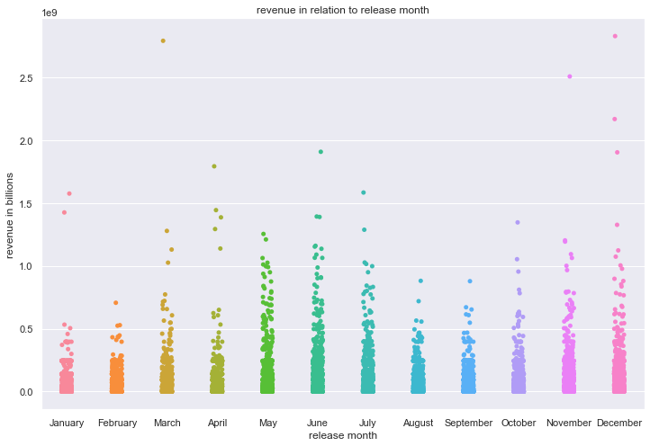

```python
plotter(df, 'release_month_name', 'revenue', 'strip', 'release month', 'revenue in billions', 'revenue in relation to release month')
```

now we are going to create a sns barplot to give a more solid sense to how far each month goes in compaison to others

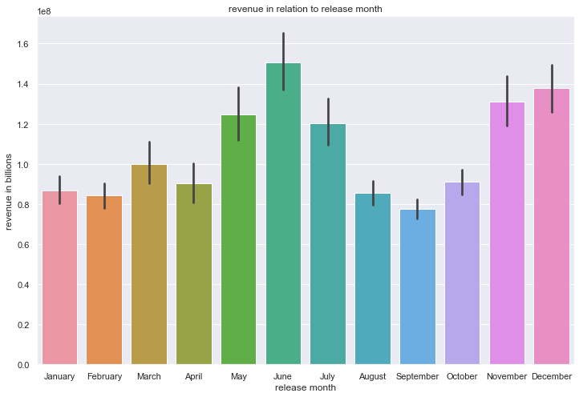

```python
plotter(df, 'release_month_name', 'revenue', 'bar', 'release month', 'revenue in billions', 'revenue in relation to release month')
```

It appears that there is a trend, except for the third quarter of the year the last month of each quarter is the highest performing in terms of revenue and it appears that December has the most extremley high values which translates to the most highest performing movies

**sub-question 1: Which quarter of the year performs generally better relative to movies of the same rating range ?**

as with months we are going to make a sns stripplot to have a wider look including extremely high values

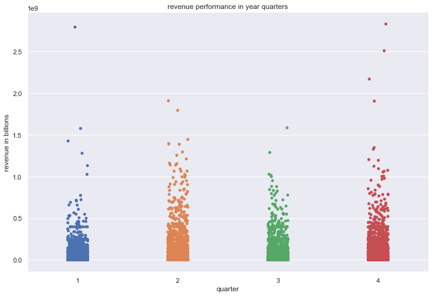

```python
plotter(df, 'quarter', 'revenue', 'strip', 'quarter', 'revenue in billions', 'revenue performance in year quarters')
```

as with months we are going to make a sns barplot to have a more solid sense of how far each quarter goes compared to other quarters

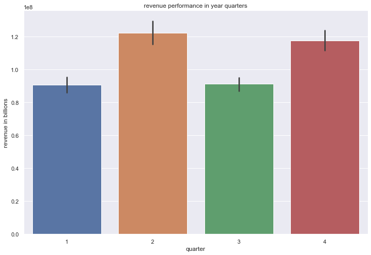

```python
plotter(df, 'quarter', 'revenue', 'bar', 'quarter', 'revenue in billions', 'revenue performance in year quarters')
```

It appears that for the highest perfomring movies the last quarter is the best performing quarter -probably because of December's performance in months, remember?-, and for most movies the 2nd quarter is the best performing quarter

```python
# creat lists to hold the desired results
group_amounts = []
group_means_revenue = []
group_means_budget = []
for i in range(2, 9):
    # create a temporary dataframe to hold filtered results for each cycle
    temporary_df = df[(df['vote_average']<i+1) & (df['vote_average']>=i)]
    group_amounts.append(temporary_df.shape[0])
    # create a trimmed dataframe to only include revenue to get some budget info and append it to specified lists for later use
    trimmed_df_revenue = temporary_df['revenue']
    # append data to its intended list
    group_means_revenue.append(trimmed_df_revenue.mean())

    # create a trimmed dataframe to only include budget to get some budget info and append it to specified lists for later use
    trimmed_df_budget = temporary_df['budget']
    # append data to its intended list
    group_means_budget.append(trimmed_df_budget.mean())
```

```python
# create dictionaries to be used and added to later
data_r = {'group amounts': group_amounts, 'group_means_revenue': group_means_revenue}
data_b = {'group amounts': group_amounts , 'group_means_budget': group_means_budget}
data_weeks = {'group amounts': group_amounts, 'group_means_revenue': group_means_revenue}
data_quarters = {'group amounts': group_amounts, 'group_means_revenue': group_means_revenue}
```

```python
# specify months, weeks, quarters to be looped over later
months = df['release_month_name'].unique()
weeks = [1, 2, 3, 4, 5]
quarters = [1, 2, 3, 4]

# creat a placeholder in the appropriate dictionary for each month of release for each of the wanted stats
for month in months :
    data_r['{}_mean'.format(month)]=[]
    data_b['{}_mean'.format(month)]=[]

# create a placeholder in the appropriate dictionary for each week of release
for week in weeks :
    data_weeks['{}_mean'.format(week)]=[]

# create a placeholder in the appropriate dictionary for each quarter
for quarter in quarters :
    data_quarters['{}_mean'.format(quarter)]=[]

# loop over months, weeks, quarters for each cycle in range of the wanted rating groups
for i in range (2,9) :
    for month in months :
        data_r['{}_mean'.format(month)].append(df.revenue[(df['release_month_name']==month) & (df['vote_average']<i+1) & (df['vote_average']>=i)].mean())
        data_b['{}_mean'.format(month)].append(df.budget[(df['release_month_name']==month) & (df['vote_average']<i+1) & (df['vote_average']>=i)].mean())
    for week in weeks :
        data_weeks['{}_mean'.format(week)].append(df.revenue[(df['week_of_month']==week) & (df['vote_average']<i+1) & (df['vote_average']>=i)].mean())
    for quarter in quarters :
        data_quarters['{}_mean'.format(quarter)].append(df.revenue[(df['quarter']==quarter) & (df['vote_average']<i+1) & (df['vote_average']>=i)].mean())
```

```python
# create a dataframe from the appropriate dictionary to display mean revenue for each quarter for each rating group
df_groups_quarters = pd.DataFrame(data_quarters, index=['R2to3', 'R3to4', 'R4to5', 'R5to6', 'R6to7', 'R7to8', 'R8to9' ])
df_groups_quarters.head(10)
```

|  | group amounts | group_means_revenue | 1_mean | 2_mean | 3_mean | 4_mean |
| --- | --- | --- | --- | --- | --- | --- |
| R2to3 | 40 | 3.171568e+05 | 5.444588e+04 | 5.000132e+04 | 7.617493e+05 | 4.666790e+04 |
| R3to4 | 230 | 1.819198e+07 | 1.703213e+07 | 1.666166e+07 | 2.018777e+07 | 1.918022e+07 |
| R4to5 | 1149 | 3.306759e+07 | 3.077036e+07 | 3.689442e+07 | 3.193393e+07 | 3.282039e+07 |
| R5to6 | 3635 | 7.524104e+07 | 6.723704e+07 | 8.684343e+07 | 6.929455e+07 | 7.920793e+07 |
| R6to7 | 4249 | 1.156945e+08 | 1.023871e+08 | 1.432387e+08 | 9.855093e+07 | 1.217260e+08 |
| R7to8 | 1470 | 2.067756e+08 | 1.795849e+08 | 2.321322e+08 | 1.746256e+08 | 2.312855e+08 |
| R8to9 | 90 | 3.500248e+08 | 4.161888e+08 | 3.632230e+08 | 3.575913e+08 | 3.077421e+08 |

now we are going to look at quarter performance for each rating group with a line plot, it can provide better views on how much each quarter revenue rises or goes down for each rating group

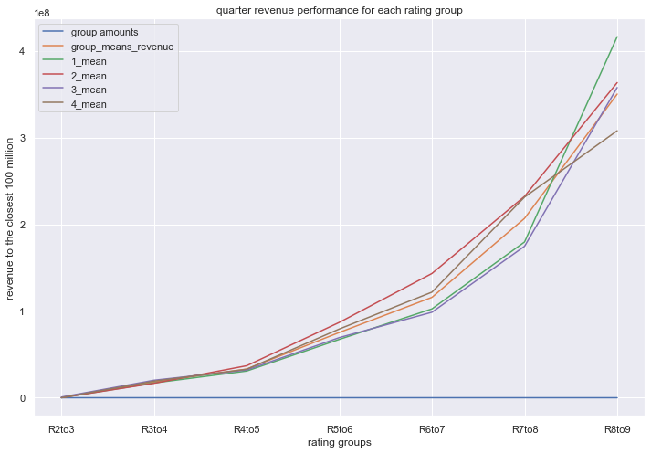

```python
df_groups_quarters.plot(xlabel='rating groups', ylabel='revenue to the closest 100 million', title='quarter revenue performance for each rating group');
```

now we are going to create a bar plot for a more solid and easier view on how much each quarter performs for each eating group compared to other quarters and rating groups

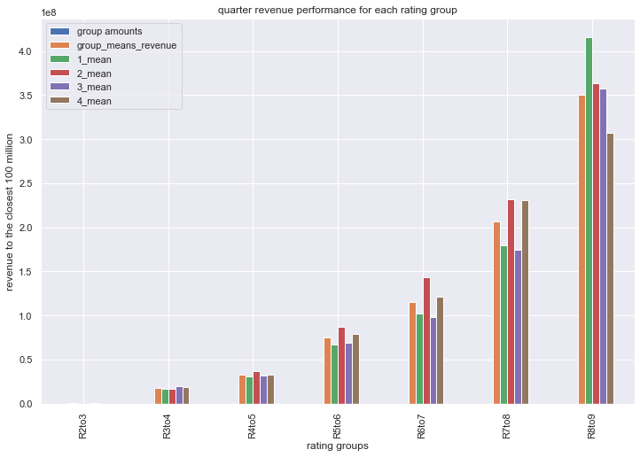

```python
df_groups_quarters.plot(xlabel='rating groups', ylabel='revenue to the closest 100 million', title='quarter revenue performance for each rating group', kind='bar');
```

It appears that for the highest rated movies -rated from 8 to 9- the 1st quarter is the best performing quarter, and for the mid-range of ratings the 2nd quarter is the best performing quarter

**Sub_question 2: - Do movies - of the same group -meaning same rating rounded to the closest integer- released in the first half of a month -when most people have most of their salary still intact- perform better in terms of revenue than those released in the latter half ?**

now we are going to create a sns stripplot to look have a wider look including the most extreme values

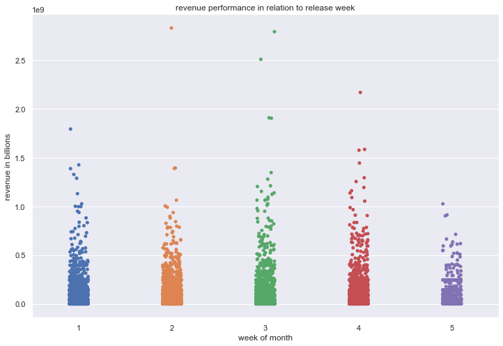

```python
plotter(df, 'week_of_month', 'revenue', 'strip', 'week of month', 'revenue in billions', 'revenue performance in relation to release week')
```

now we are going to create a sns barplot to have amore solid view on how well each week of the month performs in revenue compared to the other weeks of the month

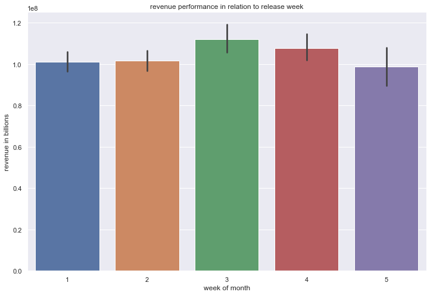

```python
plotter(df, 'week_of_month', 'revenue', 'bar', 'week of month', 'revenue in billions', 'revenue performance in relation to release week')
```

It appears that the 2nd half of the month mostly performs better than the first half, and it appears that the 3rd week has the most highest performing movies

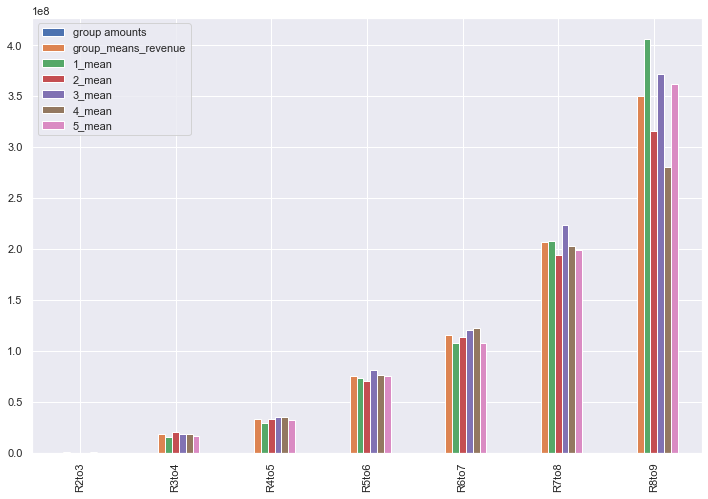

```python
# create a dataframe to display mean revenue for each release week for each rating group
df_groups_weeks = pd.DataFrame(data_weeks, index=['R2to3', 'R3to4', 'R4to5', 'R5to6', 'R6to7', 'R7to8', 'R8to9'])
df_groups_weeks.plot(kind='bar');
```

```python
# create a dataframe to display the week of maximum revenue performance for each rating group
# get the week -column- of the biggest revenue mean in each rating group by using idxmax() and using it on axis 1 the axis of the columns
# get the value of the biggest revenue mean by using max() on axis 1
data_max_weeks = {'best_performing_week': df_groups_weeks.idxmax(axis=1), 'mean_revenue': df_groups_weeks.max(axis=1)}
df_max_weeks = pd.DataFrame(data_max_weeks)
df_max_weeks.head(10)
```

|  | best_performing_week | mean_revenue |
| --- | --- | --- |
| R2to3 | 4_mean | 1.107623e+06 |
| R3to4 | 2_mean | 2.031725e+07 |
| R4to5 | 4_mean | 3.539593e+07 |
| R5to6 | 3_mean | 8.083023e+07 |
| R6to7 | 4_mean | 1.224721e+08 |
| R7to8 | 3_mean | 2.239011e+08 |
| R8to9 | 1_mean | 4.065028e+08 |

It appears that for the highest rated movies the start of the month is the best performing period, and for most other ratings the 2nd half of the month in the best performing period

**Sub-question 3: Do movies -same relative criteria mention above- released later in the month get a bit less rating in thier relative rating group -like from 7 to 8, 8 to 9 and so on- ?**

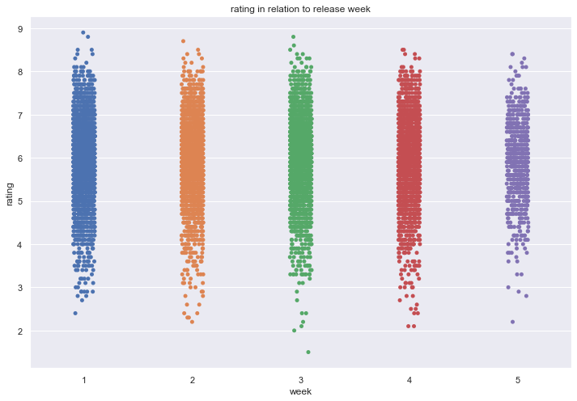

```python
plotter(df, 'week_of_month', 'vote_average', 'strip', 'week', 'rating', 'rating in relation to release week')
```

- It appears the answer is no
- week 3 has a bit more minimum ratings but there is no clear trend visible

**Further exploration**

```python
# create a dataframe from the appropriate dictionary to display mean revenue for each release month for each rating group
df_groups_r = pd.DataFrame(data_r, index=['R2to3', 'R3to4', 'R4to5', 'R5to6', 'R6to7', 'R7to8', 'R8to9' ])
df_groups_r.head(10)
```

|  | group amounts | group_means_revenue | January_mean | February_mean | March_mean | April_mean | May_mean | June_mean | July_mean | August_mean | September_mean | October_mean | November_mean | December_mean |
| --- | --- | --- | --- | --- | --- | --- | --- | --- | --- | --- | --- | --- | --- | --- |
| R2to3 | 40 | 3.171568e+05 | 5.600148e+04 | 4.666790e+04 | 7.000185e+04 | 7.000185e+04 | 7.000185e+04 | 3.500093e+04 | 7.000185e+04 | 1.552318e+06 | 7.000185e+04 | 0.000000e+00 | 7.000185e+04 | 4.666790e+04 |
| R3to4 | 230 | 1.819198e+07 | 1.605797e+07 | 1.698027e+07 | 1.800881e+07 | 1.453507e+07 | 1.939563e+07 | 1.703081e+07 | 2.403300e+07 | 1.889147e+07 | 1.786762e+07 | 1.807109e+07 | 2.464318e+07 | 1.680627e+07 |
| R4to5 | 1149 | 3.306759e+07 | 2.855121e+07 | 3.500062e+07 | 3.093040e+07 | 3.254967e+07 | 2.590548e+07 | 5.293539e+07 | 3.595315e+07 | 3.321615e+07 | 2.801579e+07 | 2.980225e+07 | 3.269812e+07 | 3.962449e+07 |
| R5to6 | 3635 | 7.524104e+07 | 6.370431e+07 | 6.395100e+07 | 7.421930e+07 | 6.850004e+07 | 8.971335e+07 | 1.027360e+08 | 9.606224e+07 | 6.938223e+07 | 5.106797e+07 | 7.169257e+07 | 8.024462e+07 | 8.838028e+07 |
| R6to7 | 4249 | 1.156945e+08 | 9.696646e+07 | 9.676286e+07 | 1.120527e+08 | 9.634528e+07 | 1.522794e+08 | 1.785410e+08 | 1.296820e+08 | 9.276482e+07 | 8.481878e+07 | 1.017995e+08 | 1.336850e+08 | 1.319650e+08 |
| R7to8 | 1470 | 2.067756e+08 | 1.813764e+08 | 1.558460e+08 | 1.996335e+08 | 2.091870e+08 | 2.297180e+08 | 2.509876e+08 | 2.379879e+08 | 1.872007e+08 | 1.391376e+08 | 1.559614e+08 | 2.900858e+08 | 2.629154e+08 |
| R8to9 | 90 | 3.500248e+08 | 4.209748e+08 | 3.965522e+08 | 4.114850e+08 | 3.965522e+08 | 1.993497e+08 | 4.613621e+08 | 5.035286e+08 | 3.036906e+08 | 2.872502e+08 | 2.469842e+08 | 3.750539e+08 | 3.206957e+08 |

```python
# create a dataframe from the appropriate dictionary to display mean revenue for each release month for each rating group
df_groups_b = pd.DataFrame(data_b, index=['R2to3', 'R3to4', 'R4to5', 'R5to6', 'R6to7', 'R7to8', 'R8to9' ])
df_groups_b.head(10)
```

|  | group amounts | group_means_budget | January_mean | February_mean | March_mean | April_mean | May_mean | June_mean | July_mean | August_mean | September_mean | October_mean | November_mean | December_mean |
| --- | --- | --- | --- | --- | --- | --- | --- | --- | --- | --- | --- | --- | --- | --- |
| R2to3 | 40 | 1.981599e+06 | 2.025573e+05 | 8.439889e+04 | 0.000000e+00 | 0.000000e+00 | 0.000000e+00 | 1.661381e+07 | 0.000000e+00 | 1.842182e+05 | 0.000000e+00 | 6.376613e+05 | 0.000000e+00 | 2.992618e+06 |
| R3to4 | 230 | 5.699129e+06 | 5.132012e+06 | 8.245240e+06 | 4.714558e+06 | 6.815979e+06 | 4.119047e+06 | 2.566195e+06 | 9.092106e+06 | 1.234642e+07 | 1.568698e+06 | 2.853142e+06 | 6.714932e+06 | 4.032494e+06 |
| R4to5 | 1149 | 9.785586e+06 | 8.335612e+06 | 9.360348e+06 | 9.790056e+06 | 1.145937e+07 | 5.784806e+06 | 2.214292e+07 | 9.024101e+06 | 1.048267e+07 | 5.886978e+06 | 5.507900e+06 | 9.806326e+06 | 1.623300e+07 |
| R5to6 | 3635 | 1.710786e+07 | 9.626172e+06 | 1.999839e+07 | 1.812987e+07 | 1.484525e+07 | 1.937335e+07 | 2.599339e+07 | 2.472083e+07 | 1.585828e+07 | 1.097241e+07 | 1.170831e+07 | 1.962562e+07 | 2.176365e+07 |
| R6to7 | 4249 | 2.014334e+07 | 7.537063e+06 | 1.488189e+07 | 1.917462e+07 | 1.705470e+07 | 2.979696e+07 | 3.059463e+07 | 2.507614e+07 | 1.508727e+07 | 1.266059e+07 | 1.801448e+07 | 2.648165e+07 | 2.810485e+07 |
| R7to8 | 1470 | 1.984420e+07 | 3.645017e+06 | 1.136794e+07 | 1.435567e+07 | 1.880186e+07 | 3.087510e+07 | 2.830600e+07 | 2.685387e+07 | 1.284399e+07 | 1.102925e+07 | 1.639761e+07 | 3.042683e+07 | 3.013477e+07 |
| R8to9 | 90 | 1.254089e+07 | 4.762877e+06 | 0.000000e+00 | 1.006155e+07 | 0.000000e+00 | 1.128337e+06 | 2.683332e+07 | 3.460781e+07 | 2.551656e+06 | 6.541688e+06 | 8.886458e+06 | 1.772983e+07 | 1.730514e+07 |

now we are going to display the best performing month for each rating group

```python
# use idxmax on the columns axis to return the column that has the maximum value at each index -rating group-
data_max_r = {'best_performing_month': df_groups_r.idxmax(axis=1), 'mean_revenue': df_groups_r.max(axis=1)}
df_max_r = pd.DataFrame(data_max_r)
df_max_r.head(10)
```

|  | best_performing_month | mean_revenue |
| --- | --- | --- |
| R2to3 | August_mean | 1.552318e+06 |
| R3to4 | November_mean | 2.464318e+07 |
| R4to5 | June_mean | 5.293539e+07 |
| R5to6 | June_mean | 1.027360e+08 |
| R6to7 | June_mean | 1.785410e+08 |
| R7to8 | November_mean | 2.900858e+08 |
| R8to9 | July_mean | 5.035286e+08 |

```python
# use idxmax on the columns axis to return the column that has the maximum value at each index -rating group-
data_max_b = {'most_costly_month': df_groups_b.idxmax(axis=1), 'mean_budget': df_groups_b.max(axis=1)}
df_max_b = pd.DataFrame(data_max_b)
df_max_b.head(10)
```

|  | most_costly_month | mean_budget |
| --- | --- | --- |
| R2to3 | June_mean | 1.661381e+07 |
| R3to4 | August_mean | 1.234642e+07 |
| R4to5 | June_mean | 2.214292e+07 |
| R5to6 | June_mean | 2.599339e+07 |
| R6to7 | June_mean | 3.059463e+07 |
| R7to8 | May_mean | 3.087510e+07 |
| R8to9 | July_mean | 3.460781e+07 |

```python
# create a dataframe to display the ratio of dividing mean revenue by mean budget as an inicator of performance
df_groups_rt = df_groups_r / df_groups_b
df_groups_rt.head(10)
```

|  | April_mean | August_mean | December_mean | February_mean | January_mean | July_mean | June_mean | March_mean | May_mean | November_mean | October_mean | September_mean | group amounts | group_means_budget | group_means_revenue |
| --- | --- | --- | --- | --- | --- | --- | --- | --- | --- | --- | --- | --- | --- | --- | --- |
| R2to3 | inf | 8.426516 | 0.015594 | 0.552945 | 0.276472 | inf | 0.002107 | inf | inf | inf | 0.000000 | inf | 1.0 | NaN | NaN |
| R3to4 | 2.132499 | 1.530117 | 4.167712 | 2.059403 | 3.128981 | 2.643282 | 6.636600 | 3.819830 | 4.708767 | 3.669907 | 6.333752 | 11.390095 | 1.0 | NaN | NaN |
| R4to5 | 2.840442 | 3.168672 | 2.440983 | 3.739243 | 3.425208 | 3.984125 | 2.390624 | 3.159369 | 4.478194 | 3.334391 | 5.410819 | 4.758943 | 1.0 | NaN | NaN |
| R5to6 | 4.614274 | 4.375142 | 4.060913 | 3.197808 | 6.617823 | 3.885882 | 3.952388 | 4.093758 | 4.630760 | 4.088769 | 6.123224 | 4.654215 | 1.0 | NaN | NaN |
| R6to7 | 5.649192 | 6.148548 | 4.695453 | 6.502054 | 12.865285 | 5.171532 | 5.835698 | 5.843799 | 5.110567 | 5.048215 | 5.650981 | 6.699433 | 1.0 | NaN | NaN |
| R7to8 | 11.125865 | 14.574970 | 8.724652 | 13.709257 | 49.760087 | 8.862333 | 8.866940 | 13.906247 | 7.440235 | 9.533883 | 9.511229 | 12.615333 | 1.0 | NaN | NaN |
| R8to9 | inf | 119.017084 | 18.531819 | inf | 88.386660 | 14.549565 | 17.193626 | 40.896776 | 176.675784 | 21.153836 | 27.793319 | 43.910715 | 1.0 | NaN | NaN |

It appears some mean budgets were had zero for a value, this is going to affect the max() function, so we are going to drop the infinity values and get the next biggest value

```python
# replace infinity values by nan values which are ignored by default by the max() and idxmax() methods
df_groups_rt.replace([np.inf, -np.inf], np.nan, inplace=True)
df_groups_rt.max(axis=1)
```

```
R2to3      8.426516
R3to4     11.390095
R4to5      5.410819
R5to6      6.617823
R6to7     12.865285
R7to8     49.760087
R8to9    176.675784
dtype: float64
```

```python
data_max_rt = {'best_performing_month': df_groups_rt.idxmax(axis=1), 'mean_ratio': df_groups_rt.max(axis=1)}
df_max_rt = pd.DataFrame(data_max_rt)
df_max_rt.head(10)
```

|  | best_performing_month | mean_ratio |
| --- | --- | --- |
| R2to3 | August_mean | 8.426516 |
| R3to4 | September_mean | 11.390095 |
| R4to5 | October_mean | 5.410819 |
| R5to6 | January_mean | 6.617823 |
| R6to7 | January_mean | 12.865285 |
| R7to8 | January_mean | 49.760087 |
| R8to9 | May_mean | 176.675784 |

## Conclusions

### further research

further research could be done with:

1. more samples of high and low rated movies
2. data on what regions make what percentage of the revenue
3. data on some user info for the accounts that rated the movie like age

in the areas of:

- the performance of top rated actors across multiple movie genres
- the performance of certain geners in certain national or international holidays & events -like how much more do romance movies make in valentine's day and how much better do horror movies perfoem in halloween season- , and in the case of international holidays & events :
  - what regions show the most correlation
  - the population of each region
  - extra info on the accounts of users who rate like age which could be really helpful in many areas like measuring the effect of certain genres on certain age groups and determining best launch windows based on work conditions across the globe for the most enthusiastic age group for each genre